# Exercise Week 2

Silvia Juen

2022-05-05

#Task 1- Import your Data ##Create a new R- (or RMarkdown-) file and begin with the following lines of code (adjust the path to your csv file accordingly)

```r
rm(list=ls())
library(readr)        # to import tabular data (e.g. csv)
library(dplyr)        # to manipulate (tabular) data
```

```r
library(ggplot2)      # to visualize data
library(sf)           # to handle spatial vector data
library(terra)        # To handle raster data
library(lubridate)    # To handle dates and times
library(gridExtra)
library(zoo)
wildschwein_BE <- read_delim("wildschwein_BE_2056.csv",",") # adjust path
wsbe_sf <- st_as_sf(wildschwein_BE, coords = c("E", "N"), crs = 2056, remove = FALSE)
```

#Task 2-getting an overview

```r
sum(is.na(wsbe_sf$DatetimeUTC))
```

```
## [1] 0
```

```r
wsbe_sf <- group_by(wsbe_sf, TierID)

wsbe_sf <- mutate(wsbe_sf, timelag = as.integer(difftime(lead(DatetimeUTC), DatetimeUTC, units = "secs")))

# NA's ?
summary(wsbe_sf$timelag)
```

```
##    Min. 1st Qu.  Median    Mean 3rd Qu.    Max.    NA's
##      12     896     903    1408     916   60367       3
```

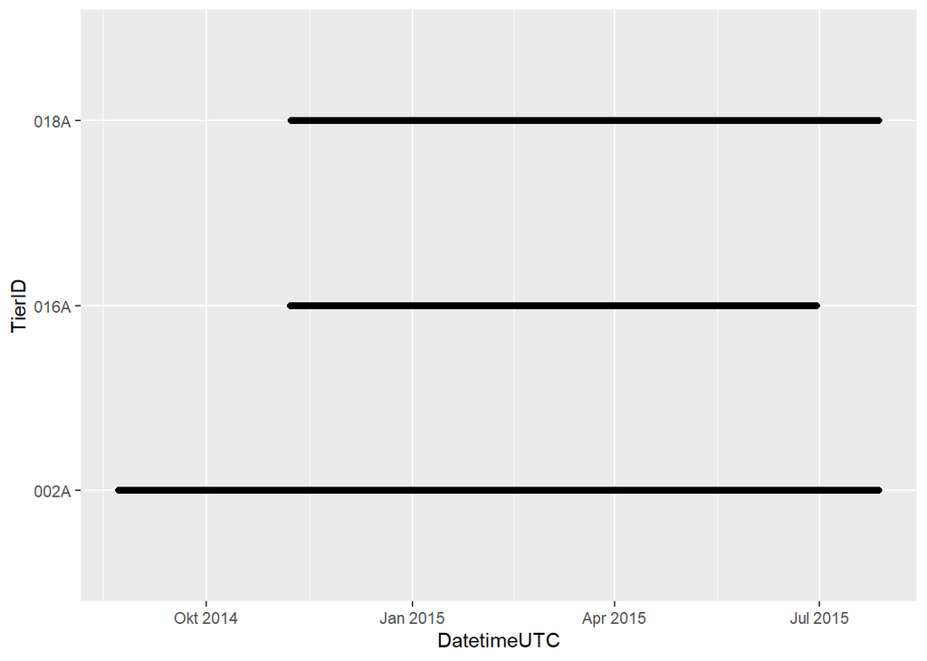

```r
ggplot(wsbe_sf, aes(x = DatetimeUTC, y = TierID)) +
    geom_point()
```

```r
range(wsbe_sf$timelag)
```

```
## [1] NA NA
```

```r
nrow(filter(wsbe_sf, timelag >= 15000))
```

```
## [1] 32
```

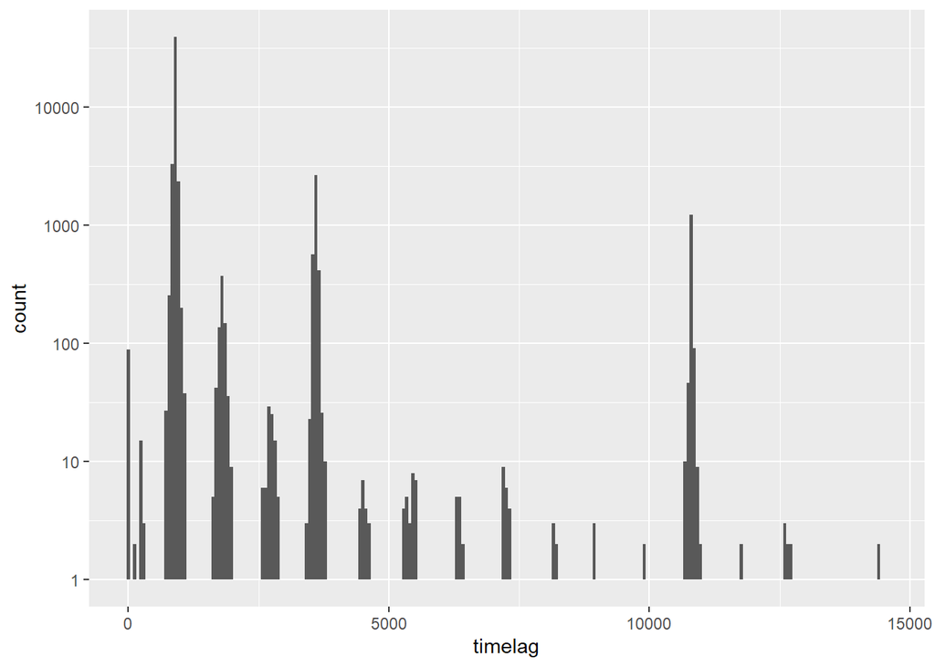

```r
wsbe_sf  %>%
    filter(timelag <= 15000) %>%
    ggplot(aes(x = timelag)) +
    geom_histogram(binwidth = 60) +
    scale_y_log10()
```

#Task3-Deriving movement parameters 1: Speed ##In this task we will derive some additional movement parameters from our trajectories. So far our trajectories only consist of a list of time-stamped spatial locations. So let’s calculate the animal’s steplength based on the Euclidean distance between two subsequent locations.

```r
wsbe_sf$steplength <- sqrt(((wsbe_sf$E - lead(wsbe_sf$E))**2) + ((wsbe_sf$N - lead(wsbe_sf$N))**2))

summary(wsbe_sf$steplength)
```

```
##    Min. 1st Qu.  Median    Mean 3rd Qu.    Max.    NA's
##    0.00    4.16   11.04   44.38   35.23 4273.51       1
```

```r
wsbe_sf$speed <- (wsbe_sf$steplength / wsbe_sf$timelag)

summary(wsbe_sf$speed)
```

```
##     Min.  1st Qu.   Median     Mean  3rd Qu.     Max.     NA's
## 0.000000 0.004053 0.011061 0.040585 0.033488 1.348674        3
```

What speed unit do you get? ## I think we get a speed unit of merters per seconds.

#Task 4- Cross-scale movement analysis Laube and Purves (2011) analyse animal movement across different scales (see below). In their paper, the authors suggest reducing the granularity of the data by subsetting the data to every nth element. We will do the same on a dataset that includes 200 locations of a single wild boar with a constant sampling interval of 60 seconds.

```r
caro <- read_delim("caro60.csv")
caro <- st_as_sf(caro, coords = c("E", "N"), crs = 2056, remove = FALSE)
class(caro)
```

```
## [1] "sf"          "spec_tbl_df" "tbl_df"      "tbl"         "data.frame"
```

```r
seq3 <- seq(1,nrow(caro),3)
caro_3 <- caro %>% slice(seq3)
```

```r
seq6 <- seq(1,nrow(caro),6)
caro_6 <- caro %>% slice(seq6)
```

```r
seq9 <- seq(1,nrow(caro),9)
caro_9 <- caro %>% slice(seq9)
```

```r
derivates <- function(sf_data){
    # timelag
    sf_data <- mutate(sf_data, timelag = as.integer(difftime(lead(sf_data$DatetimeUTC), sf_data$DatetimeUTC, units = "secs")))
    # steplength
    sf_data$steplength <- sqrt(((sf_data$E - lead(sf_data$E))**2) + ((sf_data$N - lead(sf_data$N))**2))
    # speed
    sf_data$speed <- (sf_data$steplength / sf_data$timelag)

    sf_data
}
```

```r
caro   <- derivates(caro)
caro_3 <- derivates(caro_3)
caro_6 <- derivates(caro_6)
caro_9 <- derivates(caro_9)
```

```r
traj_map <- function(original, resampled, E, N){
    plot <- ggplot() +
        geom_path( data = original,  mapping = aes({{E}}, {{N}}, colour = "cyan"), size = 0.8, alpha = 0.2) +
        geom_point(data = original,  mapping = aes({{E}}, {{N}}, colour = "cyan"), alpha = 0.2) +
        geom_path( data = resampled, mapping = aes({{E}}, {{N}}, colour = "red"),  size = 1) +
        geom_point(data = resampled, mapping = aes({{E}}, {{N}}, colour = "red"),  size = 1.2) +
        theme_bw() +
        theme(legend.justification = "right") +
        theme(plot.title = element_text(face = "bold", hjust = 0.5), legend.title = element_text(face = "bold", hjust = 0.5))

    plot
}
```

```r
# 3 minute interval
traj_3 <- traj_map(caro, caro_3, E, N) +
    scale_colour_discrete(name = "Trajectory", labels = c("1 minute", "3 minutes")) +
    labs(title = "1-Minute vs. 3-Minute sampling interval")

# 6 minute interval
traj_6 <- traj_map(caro, caro_6, E, N) +
    scale_colour_discrete(name = "Trajectory", labels = c("1 minute", "6 minutes")) +
    labs(title = "1-Minute vs. 6-Minute sampling interval")

# 9 minute interval
traj_9 <- traj_map(caro, caro_9, E, N) +
    scale_colour_discrete(name = "Trajectory", labels = c("1 minute", "9 minutes")) +
    labs(title = "1-Minute vs. 9-Minute sampling interval")
```

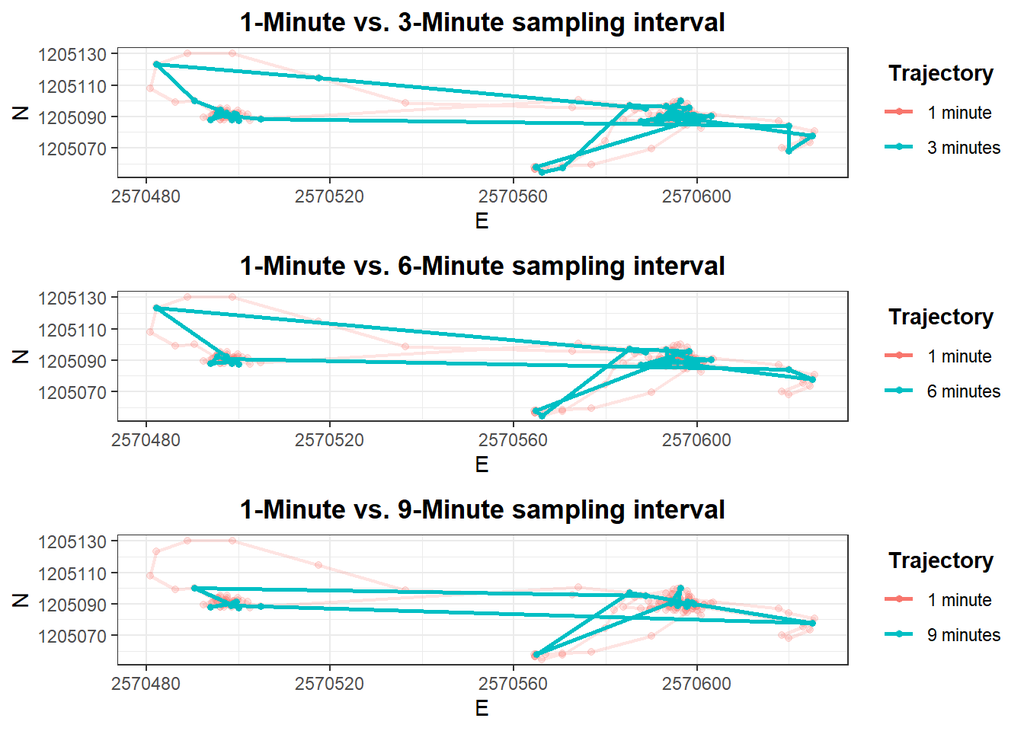

```r
grid.arrange(traj_3, traj_6, traj_9, ncol = 1)
```

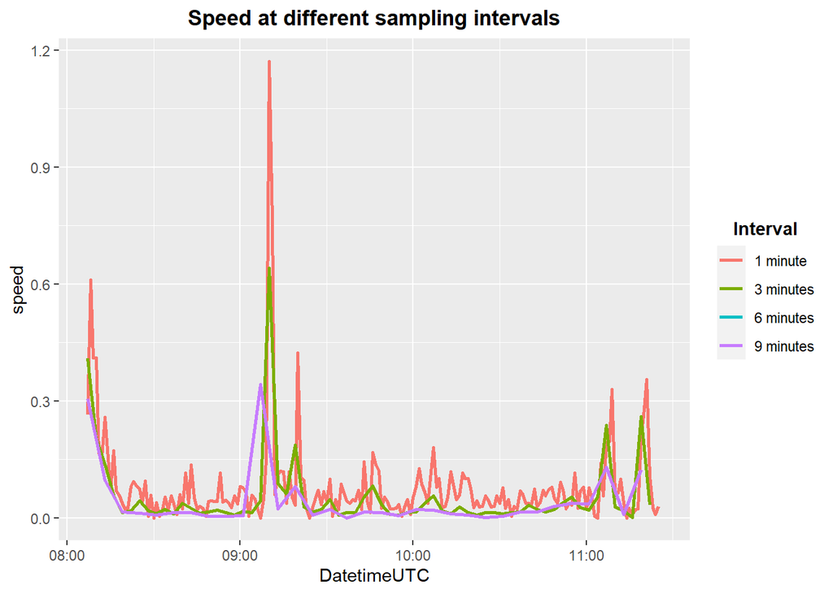

```r
ggplot(mapping = aes(x = DatetimeUTC, y = speed)) +
    geom_line(data = caro, aes(color = "1 minute"),    size = 1) +
    geom_line(data = caro_3, aes(color = "3 minutes"), size = 1) +
    geom_line(data = caro_6, aes(color = "6 minutes"), size = 1) +
    geom_line(data = caro_6, aes(color = "9 minutes"), size = 1) +
    scale_colour_discrete(name = "Interval") +
    labs(title = "Speed at different sampling intervals") +
    theme(plot.title = element_text(face = "bold", hjust = 0.5), legend.title = element_text(face = "bold", hjust = 0.5))
```

Interpret the line plot, what do the different lines for the different temporal granularities tell you? ##if you look at the diagram of speed with different intervals, you can clearly see that increasing interval decreases speed. So you can say that it is not very sensitive to the change of speed. This can be. Of course, with a larger interval, the step length can change and the position is reassigned to the animal. Nevertheless, the times are of course not representative in the case of suspension of movement or excessive movement. The granularity depends on what you want to find out. Depending on the accuracy, you have to choose a larger or smaller scale.

#Task5- Deriving movement parameters 2: Rolling window functions

```r
example <- seq(1,10)
example
```

```
##  [1]  1  2  3  4  5  6  7  8  9 10
```

```r
rollmean(example, k = 3, fill = NA, align = "left")
```

```
##  [1]  2  3  4  5  6  7  8  9 NA NA
```

```r
rollmean(example, k = 4, fill = NA, align = "left")
```

```
##  [1] 2.5 3.5 4.5 5.5 6.5 7.5 8.5  NA  NA  NA
```

```r
rollmean(example, k = 10, fill = NA, align = "left")
```

```
##  [1] 5.5  NA  NA  NA  NA  NA  NA  NA  NA  NA
```

```r
caro_k3 <- rollmean(caro$speed, k = 3, fill = NA, align = "left")
caro_k6 <- rollmean(caro$speed, k = 6, fill = NA, align = "left")
caro_k9 <- rollmean(caro$speed, k = 9, fill = NA, align = "left")
```

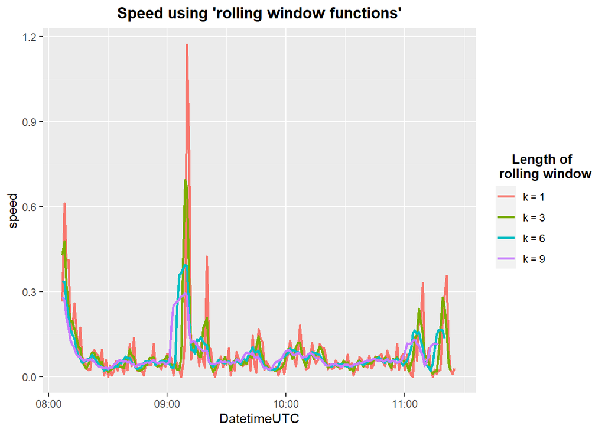

```r
ggplot(caro, aes(x = DatetimeUTC, y = speed)) +
    geom_line(aes(colour = "k = 1"), size = 1) +
    geom_line(aes(y = caro_k3, colour = "k = 3"), size = 1) +
    geom_line(aes(y = caro_k6, colour = "k = 6"), size = 1) +
    geom_line(aes(y = caro_k9, colour = "k = 9"), size = 1) +
    scale_colour_discrete(name = "Length of \n rolling window") +
    labs(title = "Speed using 'rolling window functions'") +
    theme(plot.title = element_text(face = "bold", hjust = 0.5), legend.title = element_text(face = "bold", hjust = 0.5))
```